# Lab2 Abderrhamane Adda and Zhan CHEN

## Lab2 Logistic regression from scratch

Abderrhamane Adda and Zhan CHEN

There are 3 parts in this notebook. At the first time, we implement logistric regression from scratch. Secondly, we prepare the data set for machine learning(feature engineering). And lastly, we use the prepared dataset for machine learning using logistic regression from scratch and sklearn library.

### Part 1 : implementation of logistic regression from scratch

```python
import numpy as np

class logistic_regression_from_scratch():

    def __init__(this, lr = 0.01, iteration = 1000):
        this.lr = lr
        this.iteration = iteration
        this.weights = None
        this.bias = None

    def fit(this, X, y):

        num_samples = X.shape[0]
        num_features = X.shape[1]

        this.weights = np.zeros(num_features) #initiate a weights array, whose length is equal to the number of features
        this.bias = 0 #initiately, bias = 0

    #gradient descent
        for i in range(this.iteration):

            y_predicted = this.sigmoid(np.dot(X,this.weights) + this.bias)

        #deviation of weight and bias
            dw = (1/num_samples) * np.dot(X.T, (y_predicted - y))
            db = (1/num_samples) * np.sum(y_predicted - y)

            #update weights
            this.weights = this.weights - this.lr*dw

            #update bias
            this.bias = this.bias - this.lr*db


    def sigmoid(this, x):

        return 1 / (1 + np.exp(-x))

    def predict(this,X):

        y_predicted = this.sigmoid(np.dot(X,this.weights) + this.bias)

        #if prediction > 0.5 then it is 1, else it is 0
        y_predicted_binary = [1 if p > 0.5 else 0 for p in y_predicted ]

        return y_predicted_binary

    def accuracy(this, y_true, y_predicted):

        accuracy = np.sum(y_true == y_predicted) / len(y_true)

        return accuracy
```

### Part 2 : dataset preparation

```python
import pandas as pd

df = pd.read_csv('titanic.csv')
df.info()
```

```
<class 'pandas.core.frame.DataFrame'>
RangeIndex: 891 entries, 0 to 890
Data columns (total 12 columns):
PassengerId    891 non-null int64
Survived       891 non-null int64
Pclass         891 non-null int64
Name           891 non-null object
Sex            891 non-null object
Age            714 non-null float64
SibSp          891 non-null int64
Parch          891 non-null int64
Ticket         891 non-null object
Fare           891 non-null float64
Cabin          204 non-null object
Embarked       889 non-null object
dtypes: float64(2), int64(5), object(5)
memory usage: 83.7+ KB
```

Age, Sex, and PClass seem to be good indicators of survival. let us start by visualizing 'Sex' and 'Pclass' data

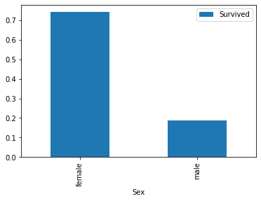

```python
import matplotlib.pyplot as plt
class_pivot = df.pivot_table(index="Sex",values="Survived")
class_pivot.plot.bar()
plt.show()
```

```python
From this barplot, we can see that female has more chances to survive
```

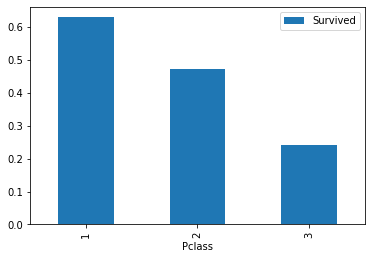

```python
class_pivot = df.pivot_table(index="Pclass",values="Survived")
class_pivot.plot.bar()
plt.show()
```

We can see from the bar plot above that people in class 1 have more chance to survive than those in class 2 and 3

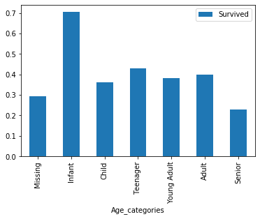

```python
def age_category(df, cut_points, label_names):
    df["Age"] = df["Age"].fillna(-0.5)
    df["Age_categories"] = pd.cut(df["Age"],cut_points,labels=label_names)
    return df

#categorize age: <0 : missing, 0<=age<5 : infant, 5<=age<12 : Chid etc.

cut_points = [-1,0,5,12,18,35,60,100]
label_names = ["Missing","Infant","Child","Teenager","Young Adult","Adult","Senior"]

df = age_category(df,cut_points,label_names)

import matplotlib.pyplot as plt
pivot = df.pivot_table(index="Age_categories",values='Survived')
pivot.plot.bar()
plt.show()
```

we can see from the above histgram chat that infant(age from 0 to 5) have largest possibility to survive

Now we need carry out one hot encoding for 'sex','age' and 'Pclass' columns

```python
def create_dummies(df,column_name):
    dummies = pd.get_dummies(df[column_name],prefix=column_name)
    df = pd.concat([df,dummies],axis=1)
    return df

for column in ["Age_categories","Pclass","Sex"]:
    df = create_dummies(df,column)

df.info()
```

```
<class 'pandas.core.frame.DataFrame'>
RangeIndex: 891 entries, 0 to 890
Data columns (total 25 columns):
PassengerId                   891 non-null int64
Survived                      891 non-null int64
Pclass                        891 non-null int64
Name                          891 non-null object
Sex                           891 non-null object
Age                           891 non-null float64
SibSp                         891 non-null int64
Parch                         891 non-null int64
Ticket                        891 non-null object
Fare                          891 non-null float64
Cabin                         204 non-null object
Embarked                      889 non-null object
Age_categories                891 non-null category
Age_categories_Missing        891 non-null uint8
Age_categories_Infant         891 non-null uint8
Age_categories_Child          891 non-null uint8
Age_categories_Teenager       891 non-null uint8
Age_categories_Young Adult    891 non-null uint8
Age_categories_Adult          891 non-null uint8
Age_categories_Senior         891 non-null uint8
Pclass_1                      891 non-null uint8
Pclass_2                      891 non-null uint8
Pclass_3                      891 non-null uint8
Sex_female                    891 non-null uint8
Sex_male                      891 non-null uint8
dtypes: category(1), float64(2), int64(5), object(5), uint8(12)
memory usage: 95.3+ KB
```

```python
#selected features
columns = ['Pclass_1', 'Pclass_2', 'Pclass_3', 'Sex_female', 'Sex_male',
       'Age_categories_Missing','Age_categories_Infant',
       'Age_categories_Child', 'Age_categories_Teenager',
       'Age_categories_Young Adult', 'Age_categories_Adult',
       'Age_categories_Senior']
```

```python
#split data to train_set and test_set
from sklearn.model_selection import train_test_split


#80% train 20% test
train_X, test_X, train_y, test_y = train_test_split(
    df[columns], df['Survived'], test_size=0.20, random_state = 0)


print(train_X.shape)   #print to check if the shape of tran_X is what we expected
print(test_X.shape)    #idem
print(train_y.shape)   #idem
print(test_y.shape)    #idem
```

```
(712, 12)
(179, 12)
(712,)
(179,)
```

### Part 3 : ML using sklearn and the logistic regression that we implemented above

```python
Using sklearn:
```

```python
from sklearn.linear_model import LogisticRegression
from sklearn.metrics import accuracy_score
lr = LogisticRegression(solver='lbfgs')
lr.fit(train_X, train_y)

predictions_train = lr.predict(train_X)
predictions_test = lr.predict(test_X)

accuracy_train = accuracy_score(train_y, predictions_train)
accuracy_test = accuracy_score(test_y, predictions_test)

print('The accuracy for train set using sklearn lib is {0:.2f}%'.format(accuracy_train*100))

print('The accuracy for train set using sklearn lib is {0:.2f}%'.format(accuracy_test*100))
```

```
The accuracy for train set using sklearn lib is 80.76%
The accuracy for train set using sklearn lib is 81.01%
```

The accuracy for both train set and test set is around 80%, which mean the model is not overfitting

```python
#logistic regression from sracth
lrfs = logistic_regression_from_scratch()  #with default parameters which are lr=0.01, n_iters=1000
lrfs.fit(train_X, train_y)

predictions_fs = lrfs.predict(test_X)

accuracy_fs = lrfs.accuracy(test_y, predictions_fs)

print('the accuracy using logistic regression from scracth is {0:.2f}% '.format(accuracy_fs*100))
```

```
the accuracy using logistic regression from scracth is 78.77%
```

Conclusion : the accurary of both logistic regression of sklearn and logistric regression from is around 80%, which means that the logistic regression from sractch is well implemented